# Introduction to RMarkdown

2021-07-14

## Introduction to R Markdown

### Agenda

- Introductions & Objectives
- Why RMarkdown?
- Basics
- PDF
- HTML
- Word
- Online Dashboards

## Introductions & Objectives

- Name and organization
- Experience with R, RStudio
- What do you hope to get out of today

## GitHub

- All the materials are hosted on my GitHub page:

https://github.com/grousell/Intro-Rmarkdown

## Why RMarkdown?

- One language is translated to different languages (HTML, LaTex, Word)
- Provides environment for data anaysis and notes
- Creates high quality reports for distribution
- Easily reproduce analyses and reports for different groups

## Getting Started

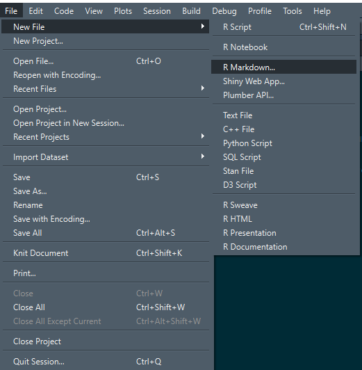

## Getting Started

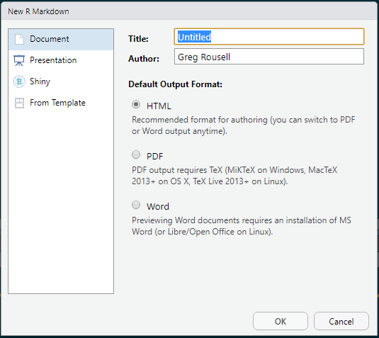

## Basics

`*Italics*`  
`**Bold**`  
`***Bold and Italics***` `'Inline Code'`  
`# First Level Heading`  
`# Second Level Heading`  
`![](images/rstudio.png)`

*Italics*  
**Bold**  
*Bold and Italics*  
Inline Code

## First Level Heading

### Second Level Heading

[figure not shown]

## Lists

- Unordered lists are started with `*` or `-`
- Ordered lists begin with a number
- Sublists are created by indenting 4 spaces, or tab

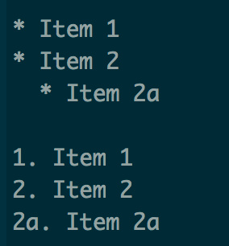

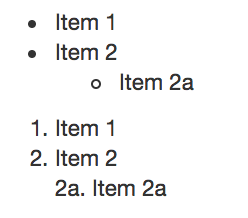

## Practice

- Open RStudio and a new RMarkdown file to create a PDF.
- Click “Run” and knit the file
- Change some text and knit again
- Try different formats (HTML, Word, PowerPoint)

## Adding R Code

[figure not shown]

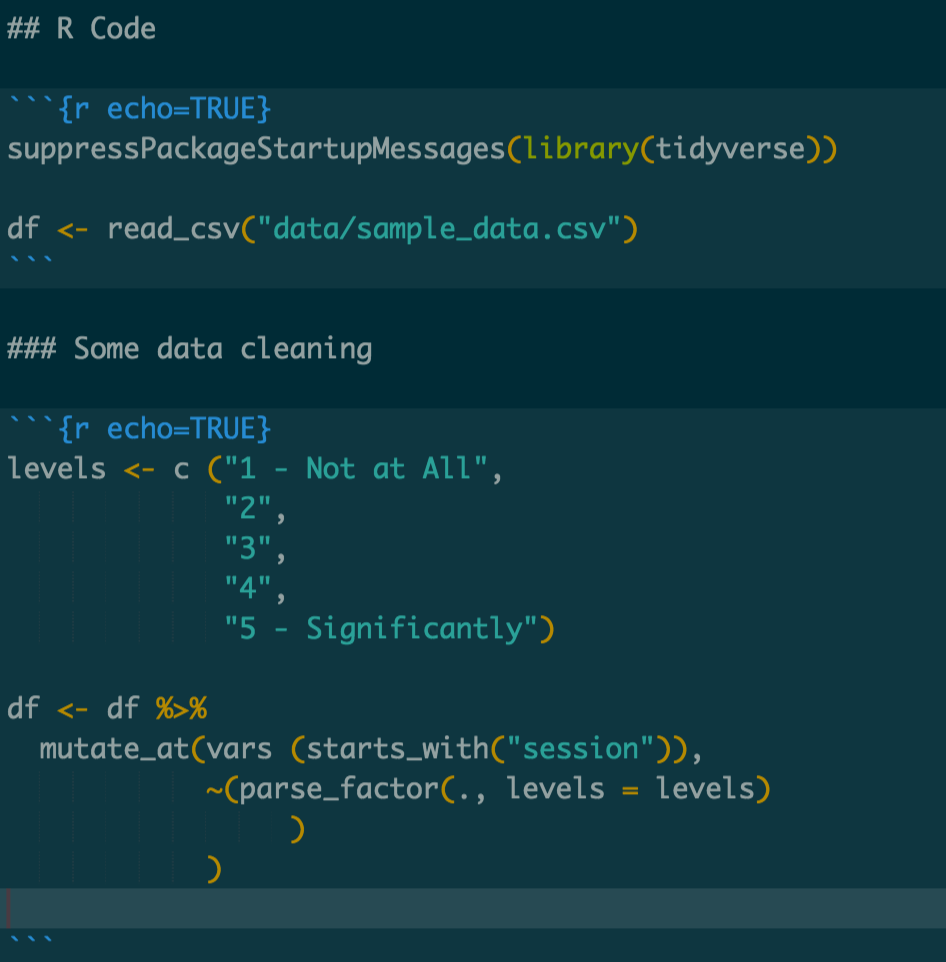

## Adding R Code

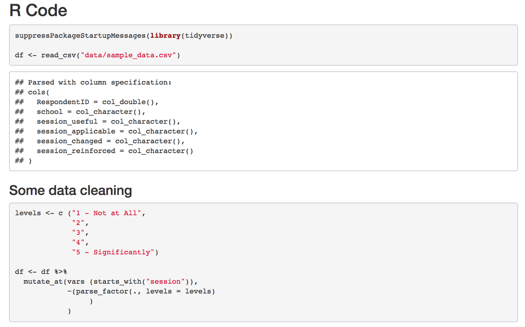

## Charts

```r
chart <- df %>%
  count (session_useful) %>%
  mutate (perc = n / sum (n)) %>%
  ggplot (aes (session_useful, perc)) +
  geom_col() +
  scale_y_continuous(labels = scales::percent_format(accuracy = 1),
                     limits = c(0,0.5)) +
  geom_text (aes (label = scales::percent(perc)),
             vjust = -1) +
  labs (title = "I found the session useful",
        x = "",
        y = "Percent")
```

## Charts

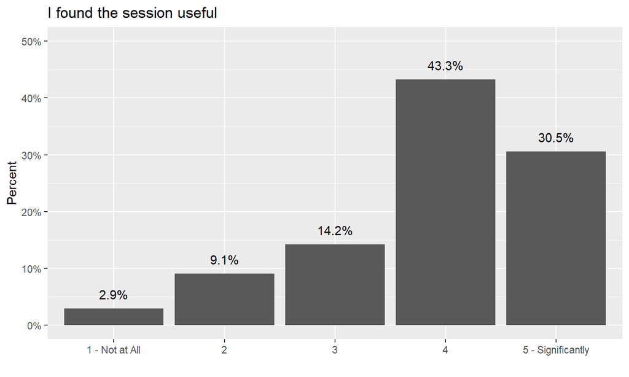

## Charts

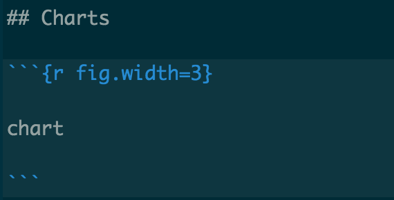

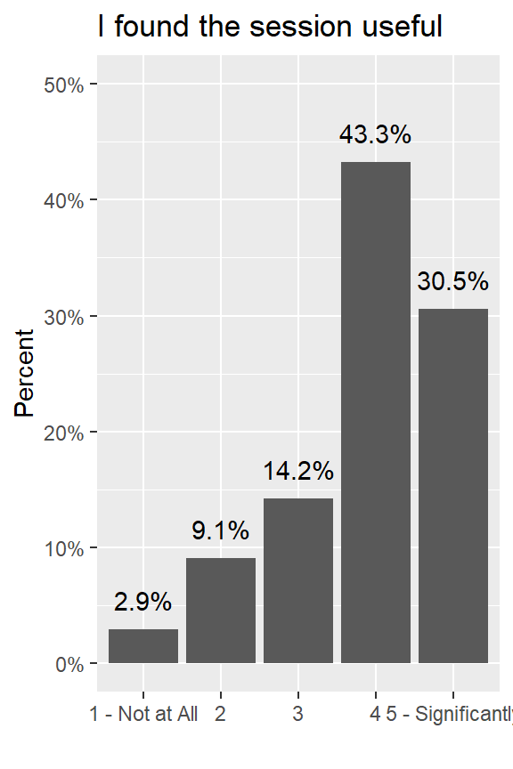

## Charts

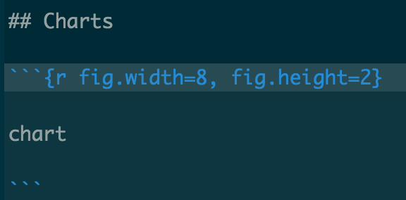

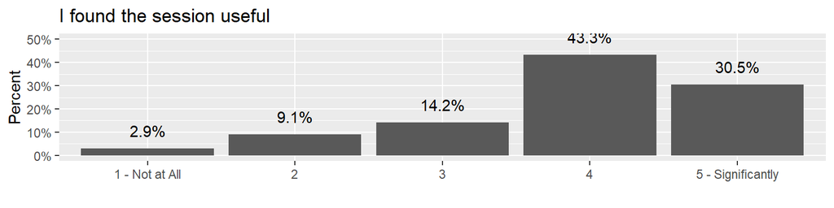

## Practice

- In practice rmd file, add a new chuck of R code and read in some data
  - df <- read_csv (“https://bit.ly/lsirm_data”)
- Create quick plot and insert into document

## Tables

```r
table <- df %>%
  count (session_useful) %>%
  rename (`I found the session useful` = session_useful) %>%
  mutate (Percent = scales::percent (n / sum (n)) )

table
```

```
## # A tibble: 5 x 3
##   `I found the session useful`     n Percent
## * <fct>                        <int> <chr>
## 1 1 - Not at All                   8 2.9%
## 2 2                               25 9.1%
## 3 3                               39 14.2%
## 4 4                              119 43.3%
## 5 5 - Significantly               84 30.5%
```

## Tables

```r
table %>%
  kable()
```

| I found the session useful | n | Percent |
| --- | --- | --- |
| 1 - Not at All | 8 | 2.9% |
| 2 | 25 | 9.1% |
| 3 | 39 | 14.2% |
| 4 | 119 | 43.3% |
| 5 - Significantly | 84 | 30.5% |

## Tables

### Formatting with `kableExtra`

#### http://haozhu233.github.io/kableExtra/awesome_table_in_html.html

```r
table %>%
  kable() %>%
  kable_styling(position = "center", font_size = 25)
```

| I found the session useful | n | Percent |
| --- | --- | --- |
| 1 - Not at All | 8 | 2.9% |
| 2 | 25 | 9.1% |
| 3 | 39 | 14.2% |
| 4 | 119 | 43.3% |
| 5 - Significantly | 84 | 30.5% |

## Tables

### Formatting with `kableExtra`

```r
table %>%
  kable(align = c ("lcc")) %>%
  kable_styling(font_size = 25) %>%
  column_spec(2:3, width = "8em")
```

| I found the session useful | n | Percent |
| --- | --- | --- |
| 1 - Not at All | 8 | 2.9% |
| 2 | 25 | 9.1% |
| 3 | 39 | 14.2% |
| 4 | 119 | 43.3% |
| 5 - Significantly | 84 | 30.5% |

## Tables

### Formatting with `kableExtra` and `formattable`

```r
table %>%
  mutate (Percent = cell_spec (Percent,
                               background = "#FA19C3"),
          n = ifelse (n > 40,
                      cell_spec (n, color = "green"),
                      cell_spec (n, color = "red"))) %>%
  kable(escape = FALSE,
        align = c ("lcc")) %>%
  kable_styling(font_size = 25) %>%
  column_spec(2:3, width = "8em")
```

## Tables

### Formatting with `kableExtra` and `formattable`

| I found the session useful | n | Percent |
| --- | --- | --- |
| 1 - Not at All | 8 | 2.9% |
| 2 | 25 | 9.1% |
| 3 | 39 | 14.2% |
| 4 | 119 | 43.3% |
| 5 - Significantly | 84 | 30.5% |

## Practice

- In practice rmd file, add a new chuck of R code and insert table into document
- Add some custome formatting
  - https://bit.ly/kable_extra
  - https://bit.ly/flextable

## Split Columns

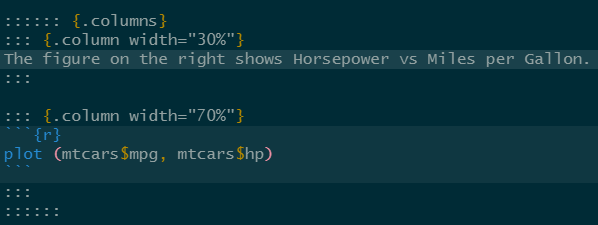

## Split Columns

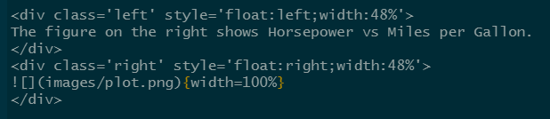

## Split Columns

[figure not shown]

## Multiple Reports - One File

```r
for (sch in unique(df$school)) {
  rmarkdown::render("Advanced_PDF_Example.Rmd",
                    output_file =  paste(sch, "_report.pdf", sep=''),
                    output_dir = './reports/')
}
```

## Practice

- Create custom report using multi-columns
- Try loop to create multiple reports